# Molluscs report

11/8/2019

## Data preparation

To collect all data from different expeditions an rbindlist function was used to compile all .csv files from different years.

```r
filenames <- list.files("~/R/Statistics-and-R-programming/data/Data/",
                        pattern="*.csv", full.names=TRUE)
data <- rbindlist(lapply(filenames,fread))
```

```
## Classes 'data.table' and 'data.frame':   4177 obs. of  9 variables:
##  $ Rings                                 : chr  "18" "14" "8" "12" ...
##  $ Sex (1 – male, 2 – female, 3 – uvenil): chr  "2" "3" "1" "1" ...
##  $ Length                                : chr  "0.575" "0.385" "0.475" "0.665" ...
##  $ Diameter                              : num  0.45 0.305 0.37 0.525 0.12 0.16 0.565 0.43 0.175 0.3 ...
##  $ Height                                : num  0.17 0.095 0.125 0.18 0.075 0.05 0.2 0.15 0.055 0.115 ...
##  $ Whole_weight                          : num  1.048 0.252 0.649 1.429 0.117 ...
##  $ Shucked_weight                        : num  0.3775 0.0915 0.347 0.6715 0.0455 ...
##  $ Viscera_weight                        : num  0.171 0.055 0.136 0.29 0.029 ...
##  $ Shell_weight                          : num  0.385 0.09 0.142 0.4 0.0345 0.015 0.494 0.221 0.018 0.0935 ...
##  - attr(*, ".internal.selfref")=<externalptr>
```

As we can already see, some data categories have wrong structure variables. This is due to incorrect format of variables in some columns such as Sex, Length and Rings.

Sex column contains variables of following levels:

```
## [1] 2 3 1 1 3 3
## Levels: 1 2 3 male one three
```

Thus we should replace levels ‘male’, ‘one’ and ‘three’ with a numeric variables and encode Sex vector as a factor using commands below:

```r
data$`Sex (1 – male, 2 – female, 3 – uvenil)` <-
  gsub(data$`Sex (1 – male, 2 – female, 3 – uvenil)`, pattern = "male", replacement = 1)
data$`Sex (1 – male, 2 – female, 3 – uvenil)` <-
  gsub(data$`Sex (1 – male, 2 – female, 3 – uvenil)`, pattern = "one", replacement = 1)
data$`Sex (1 – male, 2 – female, 3 – uvenil)` <-
  gsub(data$`Sex (1 – male, 2 – female, 3 – uvenil)`, pattern = "three", replacement = 3)
data$`Sex (1 – male, 2 – female, 3 – uvenil)` <-
  as.factor(data$`Sex (1 – male, 2 – female, 3 – uvenil)`)
```

For Rings column we can see ‘nine’ string among other numeric values:

```r
head(as.factor(data$Rings))
```

```
## [1] 18 14 8  12 4  4
## 29 Levels: 1 10 11 12 13 14 15 16 17 18 19 2 20 21 22 23 24 25 26 ... nine
```

Just as in previous case we replace string with a proper number and encode a vector as a factor:

```r
data$Rings <- gsub(data$Rings, pattern = 'nine', replacement = 9)
data$Rings <- as.factor(data$Rings)
```

Length columns contains string ‘No data! I forgot to mesure it!(’:

```r
head(as.factor(data$Length))
```

```
## [1] 0.575 0.385 0.475 0.665 0.28  0.22
## 135 Levels: 0.075 0.11 0.13 0.135 0.14 0.15 0.155 0.16 0.165 0.17 ... No data! I forgot to mesure it!(
```

Unfortunately, this string cannot be removed by gsub function, so we have to use following command to replace it with a column mean:

```r
data$Length <- as.numeric(data$Length)
mean(data$Length, na.rm = TRUE) ->
  data$Length[grep(pattern = 'No data! I forgot to mesure it!', data$Length)]
```

For the next step we have to deal with NA’s in our dataframe. To preserve as many data as possible we can replace NA’s with mean values in numeric columns. However, we should remove all the rows, containing NA’s in factor variables.

```r
data <- data[complete.cases(data$`Sex (1 – male, 2 – female, 3 – uvenil)`), ]
data <- data[complete.cases(data$Rings), ]
data <- mutate(data,
               Length = ifelse(is.na(Length), mean(Length, na.rm = TRUE), Length))
data <- mutate(data,
               Diameter = ifelse(is.na(Diameter), mean(Diameter, na.rm = TRUE), Diameter))
data <- mutate(data,
               Height = ifelse(is.na(Height), mean(Height, na.rm = TRUE), Height))
data <- mutate(data,
               Whole_weight = ifelse(is.na(Whole_weight),
                                           mean(Whole_weight, na.rm = TRUE), Whole_weight))
data <- mutate(data,
               Shucked_weight =
                 ifelse(is.na(Shucked_weight), mean(Shucked_weight, na.rm = TRUE), Shucked_weight))
data <- mutate(data,
               Viscera_weight =
                 ifelse(is.na(Viscera_weight), mean(Viscera_weight, na.rm = TRUE), Viscera_weight))
data <- mutate(data,
               Shell_weight =
                 ifelse(is.na(Shell_weight), mean(Shell_weight, na.rm = TRUE), Shell_weight))
```

## Decriptive statistics

Now as we finished data filtration we can calculate some descriptive statistics. To find mean and standart deviation of Length column I used command:

```r
length_mean_sd <- data %>% group_by(`Sex (1 – male, 2 – female, 3 – uvenil)`) %>%
  summarise(mean = mean(Length), sd = sd(Length))
```

Here you can see mean and sd for each Sex group:

| Sex (1 – male, 2 – female, 3 – uvenil) | mean | sd |
| --- | --- | --- |
| 1 | 0.5615138 | 0.1025499 |
| 2 | 0.5790484 | 0.0861998 |
| 3 | 0.4279196 | 0.1089183 |

To find relative amount of samples with Height <= 0.165 I filtered dataframe and diveded number of samples in filtered df on all samples:

```r
little <- data %>% filter(Height <= 0.165)
little_relative <- round(nrow(little)/nrow(data), 2)*100
```

This I got 76% of all samples with Height <= 0.165.

To find Length value higher than of 92% of samples i used quantile function:

```r
quantile(data$Length, probs = 0.92)
```

```
##  92%
## 0.67
```

Border value for 92% of samples is 0.67

Z scores for Length variable were performed usung scale function:

```r
Length_z_scores <- scale(data$Length)
head(Length_z_scores)
```

```
##            [,1]
## [1,]  0.4243098
## [2,] -1.1584920
## [3,] -0.4087438
## [4,]  1.1740580
## [5,] -2.0331982
## [6,] -2.5330304
```

## Comparing of two variables

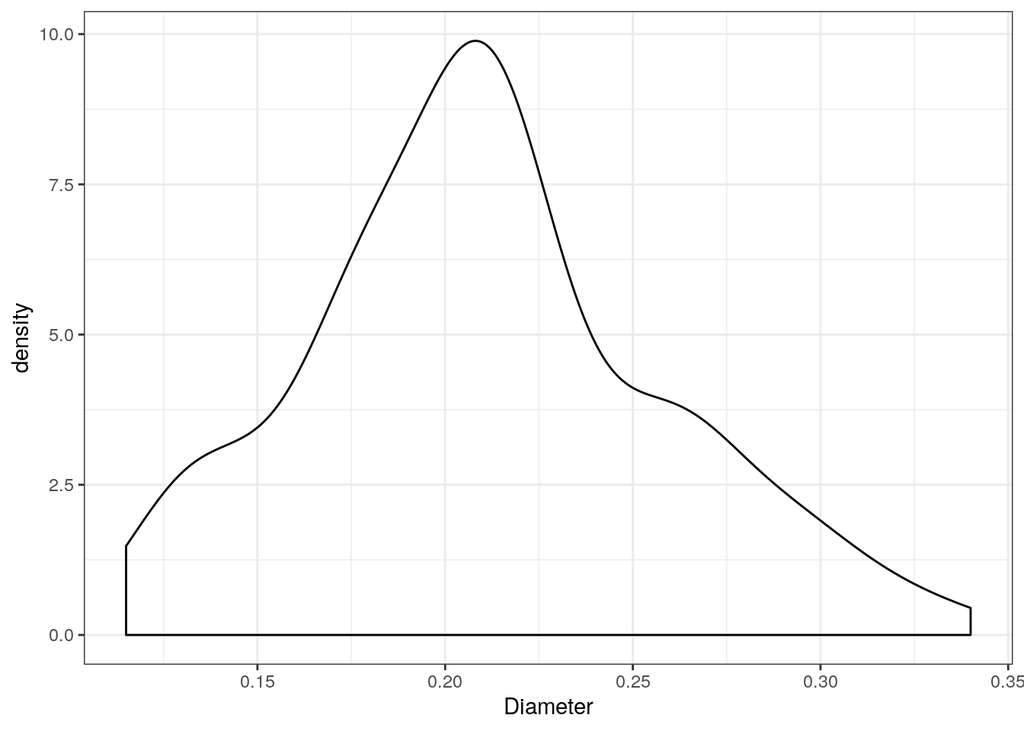

```r
rings1 <- data %>% filter(Rings == 5)
rings2 <- data %>% filter(Rings == 15)

plot1 <- ggplot(rings1, aes(Diameter))+geom_density() + theme_bw()
plot1
```

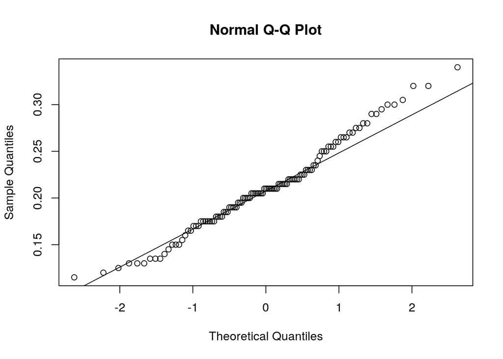

```r
qqnorm(rings1$Diameter)
qqline(rings1$Diameter)
```

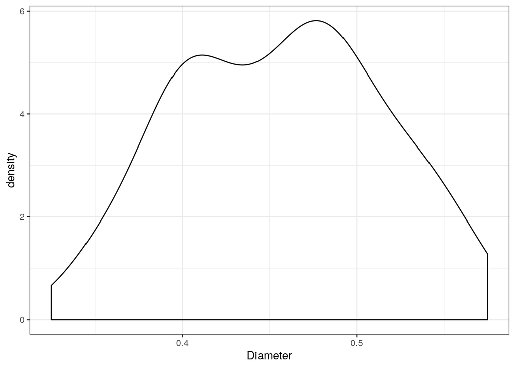

```r
plot2 <- ggplot(rings2, aes(Diameter))+geom_density() + theme_bw()
plot2
```

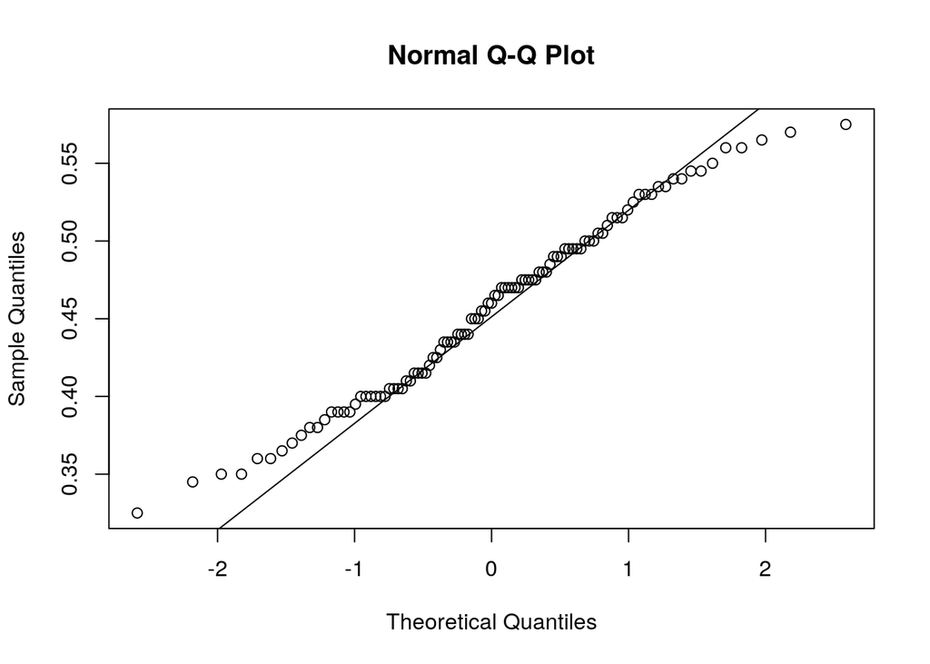

```r
qqnorm(rings2$Diameter)
qqline(rings2$Diameter)
```

On the resulting charts we see distribution close to normal in both instances. To be sure we gonna perform Shapiro-Wilcko test for normality:

```r
shapiro.test(rings1$Diameter)
```

```
##
##  Shapiro-Wilk normality test
##
## data:  rings1$Diameter
## W = 0.98162, p-value = 0.1161
```

```r
shapiro.test(rings2$Diameter)
```

```
##
##  Shapiro-Wilk normality test
##
## data:  rings2$Diameter
## W = 0.98227, p-value = 0.1836
```

Both groups have p.value > 0.05, which means normal distribution. Now when we proved normality for both groups we can perform T-test:

```r
rings_full <- rbind(rings1, rings2)
rings_full$Rings <- as.factor(rings_full$Rings)
t.test_results <- t.test(Diameter ~ Rings, data = rings_full)
t.test_results
```

```
##
##  Welch Two Sample t-test
##
## data:  Diameter by Rings
## t = 33.636, df = 195.34, p-value < 2.2e-16
## alternative hypothesis: true difference in means is not equal to 0
## 95 percent confidence interval:
##  0.2311683 0.2599647
## sample estimates:
## mean in group 15  mean in group 5
##        0.4562621        0.2106957
```

T-test showed that group’s means of Diameter statistically differ with p.value = 3.379468410^{-83}. It can be visualised with box plot:

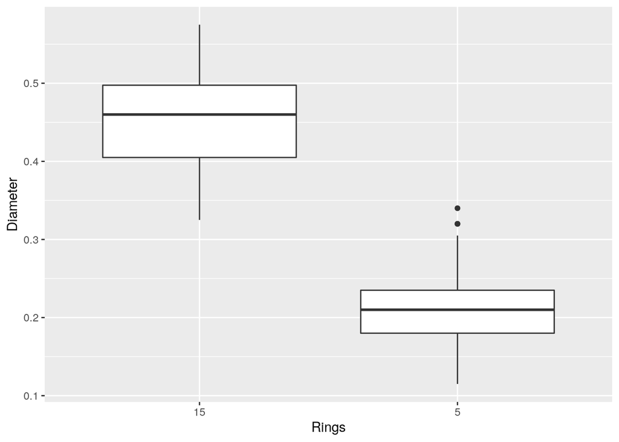

```r
ggplot(rings_full, aes(x = Rings, y = Diameter)) +
  geom_boxplot()
```

## Correlation test

Correlation between Diameter and Whole_weight can be investigated using Pearson’s correlation test. However, it has two neccessary conditions: + linear and monotone fashion of correlation + normal distribution of both variables

To check linear connection between two groups I used correlation plot:

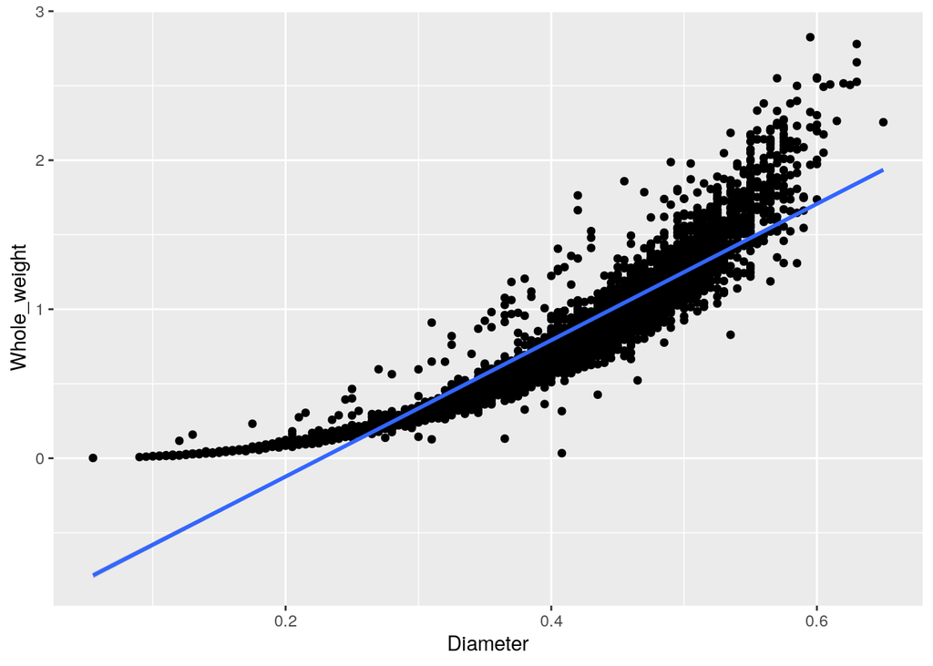

```r
ggplot(data, aes(Diameter, Whole_weight))+geom_point()+geom_smooth(method = "lm")
```

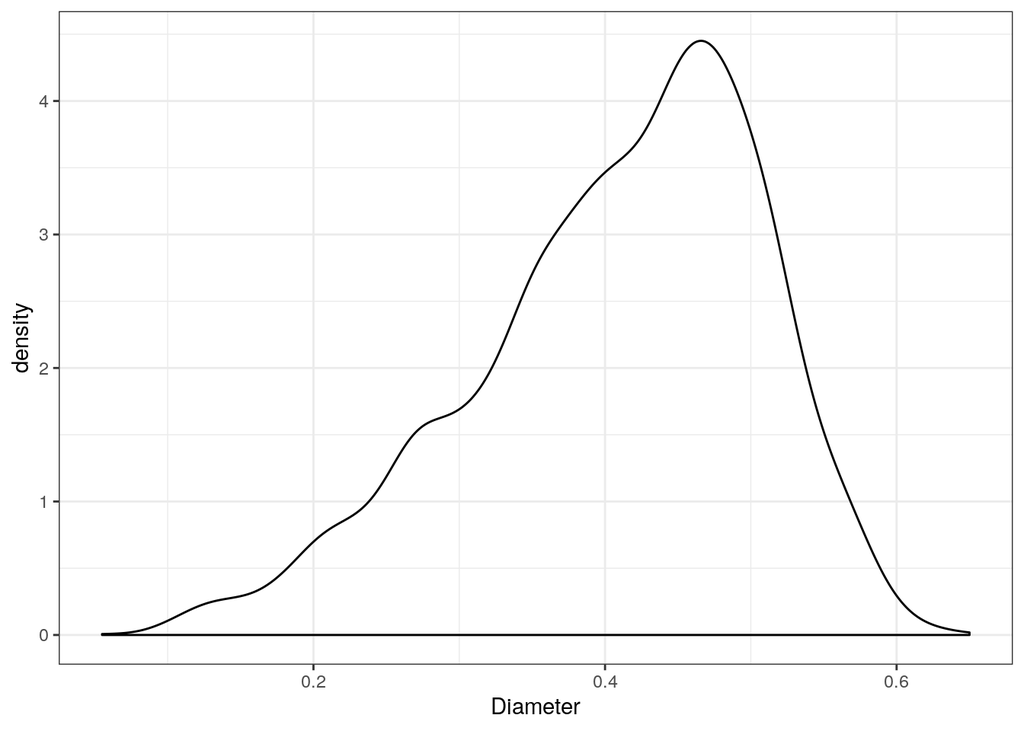

```r
ggplot(data, aes(Diameter)) + geom_density() + theme_bw()
```

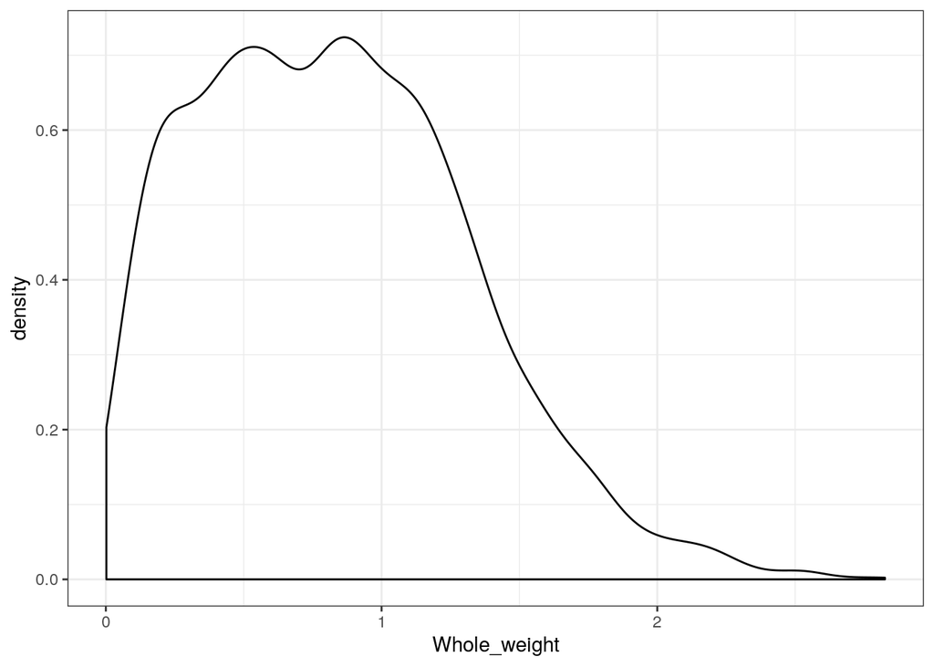

```r
ggplot(data, aes(Whole_weight)) + geom_density() + theme_bw()
```

On both density graphs we can observe skews, though graphs tend to be normal. Shapiro-Wilcko test produces following results:

```r
shapiro.test(data$Diameter)
```

```
##
##  Shapiro-Wilk normality test
##
## data:  data$Diameter
## W = 0.97065, p-value < 2.2e-16
```

```r
shapiro.test(data$Whole_weight)
```

```
##
##  Shapiro-Wilk normality test
##
## data:  data$Whole_weight
## W = 0.97226, p-value < 2.2e-16
```

p.value in both instances in way less than 0.05. Thus here I performed non-parametric analagous Spearman’s correlation test:

```r
cor.test(data$Diameter, data$Whole_weight, method = 'spearman', exact = FALSE)
```

```
##
##  Spearman's rank correlation rho
##
## data:  data$Diameter and data$Whole_weight
## S = 356421765, p-value < 2.2e-16
## alternative hypothesis: true rho is not equal to 0
## sample estimates:
##       rho
## 0.9706347
```

Still we observe strong positive correlation with p.value < 0.05.

Hope that was usefull for your research!